# PGPC blood microbiome

# Testing parameters

## Get files from PGPC website

Used this script: (Change the participants within the participants list to download a different set of files, and increase the 250 in range to make sure that all possible files are checked - the maximum necessary will be ~3000 for the genomes numbered up to 86 that are currently on the website, 20 November 2020)

```r
import os
import subprocess

participants = ['PGPC_0001', 'PGPC_0002', 'PGPC_0003', 'PGPC_0004', 'PGPC_0005']

for a in range(0, 250):
    try:
        output = subprocess.check_output("wget --spider --server-response https://personalgenomes.ca/v1/public/files/"+str(a)+"/download 2>&1 | grep -i content-disposition", shell=True)
        output = str(output)
        fn = output.split('"')[1]
        print(fn)
        if 'md5sum' not in output and 'fastq.gz' in output:
            for participant in participants:
                if participant in output:
                    if not os.path.exists(fn):
                        os.system("wget --content-disposition https://personalgenomes.ca/v1/public/files/"+str(a)+"/download")
                    else:
                        print('Already had '+fn)
    except:
        print('Didnt work '+str(a))
```

## Kneaddata parameters

### Methods

**Bowtie2 options:**  
`--very-fast`  
`--fast`  
`--sensitive`  
`--very-sensitive`  
**Running:**

```r
parallel -j 1 --link --progress 'kneaddata -i {1} -i {2} -o kneaddata_out/{3}/ \
-db /home/shared/bowtiedb/GRCh38_PhiX --trimmomatic /home/robyn/tools/Trimmomatic-0.39/ \
-t 40 --trimmomatic-options "SLIDINGWINDOW:4:20 MINLEN:50" \
--bowtie2-options "--{3} --dovetail" --remove-intermediate-output' \
 ::: cat_lanes/*_R1.fastq.gz ::: cat_lanes/*_R2.fastq.gz ::: very-fast fast sensitive very-sensitive

kneaddata_read_count_table --input very-fast --output kneaddata_read_counts_very_fast.txt
```

Tried to run this for all Bowtie2 options, but ran out of space with the intermediates (~1.5TB) after the `--very-fast` option had been run, so running the other tests like this, with the lanes still separated:

```r
 parallel -j 1 --link --progress 'kneaddata -i raw_data/PGPC_0001_S2_{1}_R1_001.fastq.gz -i raw_data/PGPC_0001_S2_{1}_R2_001.fastq.gz -o kneaddata_out/{2}/PGPC_0001_{1}/ \
-db /home/shared/bowtiedb/GRCh38_PhiX --trimmomatic /home/robyn/tools/Trimmomatic-0.39/ \
-t 40 --trimmomatic-options "SLIDINGWINDOW:4:20 MINLEN:50" \
--bowtie2-options "--{2} --dovetail" --remove-intermediate-output' \
 ::: L001 L002 L003 L004 L005 L006 L007 L008 ::: very-fast

 parallel -j 1 --link --progress 'kneaddata -i raw_data/PGPC_0001_S2_{1}_R1_001.fastq.gz -i raw_data/PGPC_0001_S2_{1}_R2_001.fastq.gz -o kneaddata_out/{2}/PGPC_0001_{1}/ \
-db /home/shared/bowtiedb/GRCh38_PhiX --trimmomatic /home/robyn/tools/Trimmomatic-0.39/ \
-t 40 --trimmomatic-options "SLIDINGWINDOW:4:20 MINLEN:50" \
--bowtie2-options "--{2} --dovetail" --remove-intermediate-output' \
 ::: L001 L002 L003 L004 L005 L006 L007 L008 ::: fast

 parallel -j 1 --link --progress 'kneaddata -i raw_data/PGPC_0001_S2_{1}_R1_001.fastq.gz -i raw_data/PGPC_0001_S2_{1}_R2_001.fastq.gz -o kneaddata_out/{2}/PGPC_0001_{1}/ \
-db /home/shared/bowtiedb/GRCh38_PhiX --trimmomatic /home/robyn/tools/Trimmomatic-0.39/ \
-t 40 --trimmomatic-options "SLIDINGWINDOW:4:20 MINLEN:50" \
--bowtie2-options "--{2} --dovetail" --remove-intermediate-output' \
 ::: L001 L002 L003 L004 L005 L006 L007 L008 ::: sensitive

 parallel -j 1 --link --progress 'kneaddata -i raw_data/PGPC_0001_S2_{1}_R1_001.fastq.gz -i raw_data/PGPC_0001_S2_{1}_R2_001.fastq.gz -o kneaddata_out/{2}/PGPC_0001_{1}/ \
-db /home/shared/bowtiedb/GRCh38_PhiX --trimmomatic /home/robyn/tools/Trimmomatic-0.39/ \
-t 40 --trimmomatic-options "SLIDINGWINDOW:4:20 MINLEN:50" \
--bowtie2-options "--{2} --dovetail" --remove-intermediate-output' \
 ::: L001 L002 L003 L004 L005 L006 L007 L008 ::: very-sensitive

#kneaddata_read_count_table --input kneaddata_out --output kneaddata_read_counts.txt
```

As the first `--very-fast` set was run when there was a lot of other stuff running on the server, re-running this here to get an accurate time:

```r
parallel -j 1 --link --progress 'kneaddata -i raw_data/PGPC_0001_S2_{1}_R1_001.fastq.gz -i raw_data/PGPC_0001_S2_{1}_R2_001.fastq.gz -o kneaddata_out/PGPC_0001_{1}_{2}/ \
-db /home/shared/bowtiedb/GRCh38_PhiX --trimmomatic /home/robyn/tools/Trimmomatic-0.39/ \
-t 40 --trimmomatic-options "SLIDINGWINDOW:4:20 MINLEN:50" \
--bowtie2-options "--{2} --dovetail" --remove-intermediate-output' \
 ::: L001 L002 L003 L004 L005 L006 L007 L008 ::: very-fast
```

### Results

As expected, Kneaddata takes longer to run as we go from very-fast to very-sensitive. The number of (paired) reads mapping to human or PhiX genomes increase as we go from very-fast (395,087,109 reads) to very-sensitive (399,505,483), while the number of (paired) reads left at the end (to be used for classification) decreases as we go from very-fast (3,437,454) to very-sensitive (2,162,939).

## Join reads

First join the paired end reads for each lane and remove the very large paired_contam files:

```r
for i in very-fast/* ; do cp $i/*kneaddata_paired* very-fast/ ; done
mkdir cat_reads_very-fast
concat_paired_end.pl -p 4 --no_R_match -o cat_reads_very-fast very-fast/*_paired_*.fastq -f
for i in very-fast/* ; do rm $i/*paired_contam* ; done

for i in fast/* ; do cp $i/*kneaddata_paired* fast/ ; done
mkdir cat_reads_fast
concat_paired_end.pl -p 4 --no_R_match -o cat_reads_fast fast/*_paired_*.fastq -f
for i in fast/* ; do rm $i/*paired_contam* ; done

for i in sensitive/* ; do cp $i/*kneaddata_paired* sensitive/ ; done
mkdir cat_reads_sensitive
concat_paired_end.pl -p 4 --no_R_match -o cat_reads_sensitive sensitive/*_paired_*.fastq -f
for i in sensitive/* ; do rm $i/*paired_contam* ; done

for i in very-sensitive/* ; do cp $i/*kneaddata_paired* very-sensitive/ ; done
mkdir cat_reads_very-sensitive
concat_paired_end.pl -p 4 --no_R_match -o cat_reads_very-sensitive very-sensitive/*_paired_*.fastq -f
for i in very-sensitive/* ; do rm $i/*paired_contam* ; done
```

Now join the lanes for each sample:

```r
concat_lanes.pl cat_reads_very-fast/* -o cat_lanes_very-fast -p 4
concat_lanes.pl cat_reads_fast/* -o cat_lanes_fast -p 4
concat_lanes.pl cat_reads_sensitive/* -o cat_lanes_sensitive -p 4
concat_lanes.pl cat_reads_very-sensitive/* -o cat_lanes_very-sensitive -p 4
```

And put all of the files into one folder (and rename):

```r
mkdir cat_lanes
mv cat_lanes_very-fast/PGPC_0001_S2_R1.fastq cat_lanes/PGPC1_very-fast.fastq
mv cat_lanes_fast/PGPC_0001_S2_R1.fastq cat_lanes/PGPC1_fast.fastq
mv cat_lanes_sensitive/PGPC_0001_S2_R1.fastq cat_lanes/PGPC1_sensitive.fastq
mv cat_lanes_very-sensitive/PGPC_0001_S2_R1.fastq PGPC1_very-sensitive.fastq

mkdir intermediates
for i in cat_reads_* ; do mv $i intermediates/ ; done
for i in cat_lanes_* ; do mv $i intermediates/ ; done

mv kneaddata_out/cat_lanes/ .
```

## Make database of GTDB + human genome

### GTDB download

Download bacterial and archaeal representative genomes from GTDB (24th November 2020, release 95):

```r
#Genomes
wget https://data.ace.uq.edu.au/public/gtdb/data/releases/latest/genomic_files_reps/gtdb_genomes_reps.tar.gz
#Metadata for bacteria and eukaryotes
wget https://data.ace.uq.edu.au/public/gtdb/data/releases/latest/bac120_metadata.tar.gz
wget https://data.ace.uq.edu.au/public/gtdb/data/releases/latest/ar122_metadata.tar.gz

#Unzip
tar -xf gtdb_genomes_reps.tar.gz
tar -xf bac120_metadata.tar.gz
tar -xf ar122_metadata.tar.gz

rm gtdb_genomes_reps.tar.gz
rm bac120_metadata.tar.gz
rm ar122_metadata.tar.gz
```

### Human download

Download the human genome from NCBI:  
Using my script created previously for [Kraken2 NCBI databases](https://github.com/R-Wright-1/peptides)

```r
python download_domain.py --domain vertebrate_mammalian --complete True --ext dna --human False
```

Note that this already changes the fasta headers to match those expected by Kraken2.

### Make database as done previously

Tried just editing all fasta IDs/descriptions to match NCBI taxonomy (as I did when I was making the protein database for Kraken). Ultimately didn’t work because only a small number of the taxid’s for the GTDB genomes actually match what is expected from the NCBI taxonomy.

Example header of Kraken2 compatible fasta file  
`>NC_000001.11|kraken:taxid|9606 NC_000001.11 Homo sapiens chromosome 1, GRCh38.p13 Primary Assembly`  
Example header of current GTDB fasta file  
`>NZ_SLZW01000001.1 Varunaivibrio sulfuroxidans strain DSM 101688 Ga0244726_101, whole genome shotgun sequence`  
File name: `GCF_004341725.1_genomic.fna.gz`  
Change the fasta file headers to match the NCBI taxonomy expected by Kraken2:  
(Didn’t remove the original files within this script just incase something went wrong, but by uncommenting the line at the bottom of the for loop - os.system(rm….. - this would do this)

```r
import pandas as pd
from Bio import SeqIO
from Bio.SeqRecord import SeqRecord
import os

bacteria, archaea = pd.read_csv('bac120_metadata_r95.tsv', index_col=0, header=0, sep='\t'), pd.read_csv('ar122_metadata_r95.tsv', index_col=0, header=0, sep='\t')

bac_red = bacteria.loc[:, ['gtdb_taxonomy', 'ncbi_genbank_assembly_accession', 'ncbi_organism_name', 'ncbi_taxid', 'gtdb_genome_representative']]
arc_red = archaea.loc[:, ['gtdb_taxonomy', 'ncbi_genbank_assembly_accession', 'ncbi_organism_name', 'ncbi_taxid', 'gtdb_genome_representative']]

all_red = pd.concat([bac_red, arc_red])
acc_dict = {}

count = 0
genomes = list(all_red.index.values)
for genome in genomes:
  gtdb_tax, assembly, ncbi_name, taxid, gtdb_genome = all_red.loc[genome, :].values
  species = gtdb_tax.split('s__')[1]
  if gtdb_genome.count('_') == 2:
    gtdb_genome_red = gtdb_genome.split("_", 1)[1]
    gtdb_genome = gtdb_genome_red
  acc_dict[gtdb_genome] = [taxid, species]

fol = 'gtdb_genomes_reps_r95/'
files = os.listdir(fol)
logfile = []
for f in files:
  if '.fna' not in f:
    logfile.append(f+': not a .fna file, skipped this file')
    continue
  if 'tax' in f:
    logfile.append(f+': already had a .tax.fna.gz, skipped this file')
    continue
  elif os.path.exists(fol+f.split('.fna')[0]+".tax.fna.gz"):
    logfile.append(f+': already had a .tax.fna.gz, skipped this file')
    continue
  f = f.split('.gz')[0]
  acc = f.split("_")
  acc = acc[0]+'_'+acc[1]
  taxid, species = acc_dict[acc]
  ff_unzip = "gunzip "+fol+f+".gz"
  try: os.system(ff_unzip)
  except: already_unzipped = True
  records = SeqIO.parse(fol+f, "fasta")
  new_records = []
  for record in records:
    newid = record.id+"|kraken:taxid|"+str(taxid)
    newdescr = record.description+', GTDB species: '+species
    newseq = SeqRecord(record.seq, id=newid, description=newdescr)
    new_records.append(newseq)
  SeqIO.write(new_records, fol+f.split('.fna')[0]+".tax.fna", "fasta")
  if taxid != 'none':
    logfile.append(f+'.gz: changed the fasta headers for this file')
  else:
    logfile.append(f+'.gz: changed the fasta headers for this file, but the NCBI taxonomy ID was missing')
  ff_zip = "gzip "+fol+f.split('.fna')[0]+".tax.fna"
  ff_zip_orig = "gzip "+fol+f
  os.system(ff_zip)
  os.system(ff_zip_orig)
  #os.system("rm "+fol+f+'.gz')

with open("logfile.txt", 'w') as f:
    for row in logfile:
        f.write(row+'\n')
```

This was uploaded as a single script to the server and run as follows:

```r
python change_fasta_headers.py
```

Move these .tax.fna.gz files to a new folder (not necessary if the originals were removed within the loop above):

```r
mkdir gtdb_genomes_reps_r95_tax/
for i in gtdb_genomes_reps_r95/*.tax.fna.gz ; do mv $i gtdb_genomes_reps_r95_tax/ ; done
for i in gtdb_genomes_reps_r95/* ; do gzip $i ; done
```

The taxa with a kraken taxid of ‘none’ can’t be added to kraken, so removing these from the new folder as follows:

```r
import os
import pandas as pd

fol = 'gtdb_genomes_reps_r95_tax/'
new_fol = 'gtdb_genomes_reps_r95_tax_not_adding/'

bacteria, archaea = pd.read_csv('bac120_metadata_r95.tsv', index_col=0, header=0, sep='\t'), pd.read_csv('ar122_metadata_r95.tsv', index_col=0, header=0, sep='\t')

bac_red = bacteria.loc[:, ['gtdb_taxonomy', 'ncbi_genbank_assembly_accession', 'ncbi_organism_name', 'ncbi_taxid', 'gtdb_genome_representative']]
arc_red = archaea.loc[:, ['gtdb_taxonomy', 'ncbi_genbank_assembly_accession', 'ncbi_organism_name', 'ncbi_taxid', 'gtdb_genome_representative']]

all_red = pd.concat([bac_red, arc_red])
genomes = list(all_red.index.values)

remove = []
for genome in genomes:
  gtdb_tax, assembly, ncbi_name, taxid, gtdb_genome = all_red.loc[genome, :].values
  if gtdb_genome.count('_') == 2:
    gtdb_genome_red = gtdb_genome.split("_", 1)[1]
    gtdb_genome = gtdb_genome_red
  if taxid == 'none':
    remove.append(gtdb_genome)

files = os.listdir(fol)
for fi in files:
  for gtdb in remove:
    if gtdb in fi:
      os.system('mv '+fol+fi+' '+new_fol)
      continue
```

There are 153 archaeal genomes with no NCBI taxonomy ID, but only 113 genomes get removed. Not really sure why this is.

Modifying the original code to not create the .tax files for those with no taxid and to not gzip the .tax files:

```r
import pandas as pd
from Bio import SeqIO
from Bio.SeqRecord import SeqRecord
import os

bacteria, archaea = pd.read_csv('bac120_metadata_r95.tsv', index_col=0, header=0, sep='\t'), pd.read_csv('ar122_metadata_r95.tsv', index_col=0, header=0, sep='\t')

bac_red = bacteria.loc[:, ['gtdb_taxonomy', 'ncbi_genbank_assembly_accession', 'ncbi_organism_name', 'ncbi_taxid', 'gtdb_genome_representative']]
arc_red = archaea.loc[:, ['gtdb_taxonomy', 'ncbi_genbank_assembly_accession', 'ncbi_organism_name', 'ncbi_taxid', 'gtdb_genome_representative']]

all_red = pd.concat([bac_red, arc_red])
acc_dict = {}

genomes = list(all_red.index.values)
for genome in genomes:
  gtdb_tax, assembly, ncbi_name, taxid, gtdb_genome = all_red.loc[genome, :].values
  species = gtdb_tax.split('s__')[1]
  if gtdb_genome.count('_') == 2:
    gtdb_genome_red = gtdb_genome.split("_", 1)[1]
    gtdb_genome = gtdb_genome_red
  acc_dict[gtdb_genome] = [taxid, species]

fol = 'gtdb_genomes_reps_r95/'
files = os.listdir(fol)
logfile = []
for f in files:
  if '.fna' not in f:
    logfile.append(f+': not a .fna file, skipped this file')
    continue
  if 'tax' in f:
    logfile.append(f+': already had a .tax.fna.gz, skipped this file')
    continue
  elif os.path.exists(fol+f.split('.fna')[0]+".tax.fna.gz"):
    logfile.append(f+': already had a .tax.fna.gz, skipped this file')
    continue
  f = f.split('.gz')[0]
  acc = f.split("_")
  acc = acc[0]+'_'+acc[1]
  taxid, species = acc_dict[acc]
  if taxid == 'none':
    logfile.append(f+'.gz: NCBI taxonomy ID was missing so skipped this file')
    continue
  ff_unzip = "gunzip "+fol+f+".gz"
  try: os.system(ff_unzip)
  except: already_unzipped = True
  records = SeqIO.parse(fol+f, "fasta")
  new_records = []
  for record in records:
    newid = record.id+"|kraken:taxid|"+str(taxid)
    newdescr = record.description+', GTDB species: '+species
    newseq = SeqRecord(record.seq, id=newid, description=newdescr)
    new_records.append(newseq)
  SeqIO.write(new_records, fol+f.split('.fna')[0]+".tax.fna", "fasta")
  if taxid != 'none':
    logfile.append(f+'.gz: changed the fasta headers for this file')
  else:
    logfile.append(f+'.gz: changed the fasta headers for this file, but the NCBI taxonomy ID was missing')
  ff_zip = "gzip "+fol+f.split('.fna')[0]+".tax.fna"
  ff_zip_orig = "gzip "+fol+f
  #os.system(ff_zip)
  os.system(ff_zip_orig)
  #os.system("rm "+fol+f+'.gz')

with open("logfile_2.txt", 'w') as f:
    for row in logfile:
        f.write(row+'\n')
```

#### Combine and make the database

This takes a few hours to complete

```r
#get NCBI taxonomy
kraken2-build --download-taxonomy --db gtdb_human --use-ftp

#add human genome
kraken2-build --add-to-library vertebrate_mammalian/GCF_000001405.39_GRCh38.p13_genomic.tax.fna --db gtdb_human

#for file in gtdb_genomes_reps_r95_tax/*.fna.gz ; do gunzip $file ; done

#add all bacterial and archaeal genomes (aside from those with no NCBI taxonomy)
for file in gtdb_genomes_reps_r95_tax/*.fna
do
    kraken2-build --add-to-library $file --db gtdb_human --threads 8
done

for file in gtdb_genomes_reps_r95_tax/*.fna ; do gunzip $file ; done

#build the database
kraken2-build --build --db gtdb_human --threads 20
```

Apparently this didn’t work, so checking whether all taxonomy IDs are in the mapping file downloaded from NCBI:

```r
import pickle
import pandas as pd

gb = pd.read_csv('gtdb_human/taxonomy/nucl_gb.accession2taxid', sep='\t', header=0)
#taxid_gb = gb.loc[:, 'taxid'].values
gi_gb = gb.loc[:, 'gi'].values
wgs = pd.read_csv('gtdb_human/taxonomy/nucl_wgs.accession2taxid', sep='\t', header=0)
#taxid_wgs = wgs.loc[:, 'taxid'].values
gi_wgs = wgs.loc[:, 'gi'].values
#taxid_list = list(set(list(taxid_gb)+list(taxid_wgs)))
gi_list = list(set(list(gi_gb)+list(gi_wgs)))

with open('taxid.list', 'wb') as f:
    pickle.dump(taxid_list, f)

with open('gi.list', 'wb') as f:
    pickle.dump(gi_list, f)

with open('taxid.list', 'rb') as f:
    taxid_list = set(pickle.load(f))

bacteria, archaea = pd.read_csv('bac120_metadata_r95.tsv', index_col=0, header=0, sep='\t'), pd.read_csv('ar122_metadata_r95.tsv', index_col=0, header=0, sep='\t')

bac_red = bacteria.loc[:, ['gtdb_taxonomy', 'ncbi_genbank_assembly_accession', 'ncbi_organism_name', 'ncbi_taxid', 'gtdb_genome_representative', 'ncbi_species_taxid']]
arc_red = archaea.loc[:, ['gtdb_taxonomy', 'ncbi_genbank_assembly_accession', 'ncbi_organism_name', 'ncbi_taxid', 'gtdb_genome_representative', 'ncbi_species_taxid']]

all_red = pd.concat([bac_red, arc_red])
taxid_not_in_list = []

genomes = list(all_red.index.values)
for genome in genomes:
  gtdb_tax, assembly, ncbi_name, taxid, gtdb_genome, sp_taxid = all_red.loc[genome, :].values
  if gtdb_genome.count('_') == 2:
    gtdb_genome_red = gtdb_genome.split("_", 1)[1]
    gtdb_genome = gtdb_genome_red
  if taxid not in taxid_list and sp_taxid not in taxid_list:
    taxid_not_in_list.append([gtdb_genome, taxid])

with open('taxid_not_in_list.list', 'wb') as f:
    pickle.dump(taxid_not_in_list, f)

# with open('taxid_not_in_list.list', 'rb') as f:
#     taxid_not_in_list = pickle.load(f)
```

Looks like 5009 genomes (not including ’none’s) are not in the taxonomy list. From a quick look, it appears as if while they do have NCBI taxid’s assigned, that I can find on the NCBI website, they aren’t taxonomically classified, e.g. `taxid: 1131273` is `Bacteria; FCB group; Candidatus Marinimicrobia`. So I’ll have to try making my own taxonomy as suggested in Struo and GTDB_Kraken.

### GTDB_Kraken

GTDB_Kraken Following the build from source instructions

1. Creating a .tsv file formatted as in the example [here](https://github.com/hcdenbakker/GTDB_Kraken/blob/master/data/gtdb.2018-12-10.tsv), a tab-delimited file with the genome in the first column, the taxonomic classification in the second column (colon separated d__Kingdom;p__Phylum;c__Class;o__Order;f__Family;g__Genus;s__Species) and no header:

```r
import pandas as pd

bac, arc = pd.read_csv('/Users/robynwright/Documents/OneDrive/Langille_Lab_postdoc/Human_blood_metagenome/GTDB_human_db/bac120_metadata_r95.tsv', header=0, index_col=0, sep='\t'), pd.read_csv('/Users/robynwright/Documents/OneDrive/Langille_Lab_postdoc/Human_blood_metagenome/GTDB_human_db/ar122_metadata_r95.tsv', header=0, index_col=0, sep='\t')

bac = bac.loc[:, 'gtdb_taxonomy']
arc = arc.loc[:, 'gtdb_taxonomy']

bac_arc = pd.concat([bac, arc])

bac_arc.to_csv('/Users/robynwright/Documents/OneDrive/Langille_Lab_postdoc/Human_blood_metagenome/GTDB_human_db/gtdb.2020-11-30.tsv', sep='\t', header=False)
```

2. Copy this to the server

```r
scp gtdb.2020-11-30.tsv robyn@vulcan.pharmacology.dal.ca:/home/robyn/tools/kraken_gtdb_human/
scp scp gtdbToTaxonomy.pl robyn@vulcan.pharmacology.dal.ca:/home/robyn/tools/kraken_gtdb_human/
```

3. Make sure the folder setup is the same as theirs gtdb_human data gtdb.2020-11-30.tsv scripts gtdbToTaxonomy.pl
4. Run the taxonomy script:

```r
perl scripts/gtdbToTaxonomy.pl --infile data/gtdb.2020-11-30.tsv
```

Looking at the first output:

```r
_A anthracis
scripts/gtdbToTaxonomy.pl   finding it (GCA_000006155)...from NCBI using esearch (GCA_000006155)...got it!

scripts/gtdbToTaxonomy.pl Loading GCA_000007385, d__Bacteria;p__Prote...eae;g__Xanthomonas;s__Xanthomonas oryzae
scripts/gtdbToTaxonomy.pl   finding it (GCA_000007385)...from NCBI using esearch (GCA_000007385)...got it!

scripts/gtdbToTaxonomy.pl Loading GCA_000008605, d__Bacteria;p__Spiro...aceae;g__Treponema;s__Treponema pallidum
scripts/gtdbToTaxonomy.pl   finding it (GCA_000008605)...from NCBI using esearch (GCA_000008605)...got it!

scripts/gtdbToTaxonomy.pl Loading GCA_000010565, d__Bacteria;p__Firmi...culum;s__Pelotomaculum thermopropionicum
scripts/gtdbToTaxonomy.pl   finding it (GCA_000010565)...from NCBI using esearch (GCA_000010565)...got it!

scripts/gtdbToTaxonomy.pl Loading GCA_000013845, d__Bacteria;p__Firmi...ostridium_P;s__Clostridium_P perfringens
scripts/gtdbToTaxonomy.pl   finding it (GCA_000013845)...from NCBI using esearch (GCA_000013845)...got it!

scripts/gtdbToTaxonomy.pl Loading GCA_000014305, d__Bacteria;p__Firmi...e;g__Streptococcus;s__Streptococcus suis
scripts/gtdbToTaxonomy.pl   finding it (GCA_000014305)...from NCBI using esearch (GCA_000014305)...got it!
```

So it looks like this is getting the NCBI taxonomy, which we don’t want (maybe it worked when they made this script in 2018, or with the 2018 version, but doesn’t seem to work here.)

### Struo

Struo Seeing as I have already downloaded all of the GTDB genomes that I want I won’t follow the instructions completely.

1. Run the gtdb_to_taxdump: This script allows you to make a kraken-compatible taxonomy with one or more input tsv files, which should have (at a minimum) the ‘accession’ in the first column and the ‘gtdb_taxonomy’ in the second column.  
   So we can use the bacteria and archaea .tsv files that were downloaded from the GTDB website and we’ll also add the human genome to this (this could be made this way for anything, just need a dictionary of genomes with corresponding taxonomy):

```python
import pandas as pd

genomes = {'GCF_000001405.39':'d__Animalia;p__Chordata;c__Mammalia;o__Primates;f__Hominidae;g__Homo;s__Homo sapiens'}

genome_pd = pd.DataFrame.from_dict(genomes, orient='index').reset_index()#, columns=['accession', 'gtdb_taxonomy'])
genome_pd = genome_pd.rename(columns={'index':'accession', 0:'gtdb_taxonomy'})

bac, arc = pd.read_csv('/Users/robynwright/Documents/OneDrive/Langille_Lab_postdoc/Human_blood_metagenome/GTDB_human_db/bac120_metadata_r95.tsv', header=0, sep='\t'), pd.read_csv('/Users/robynwright/Documents/OneDrive/Langille_Lab_postdoc/Human_blood_metagenome/GTDB_human_db/ar122_metadata_r95.tsv', header=0, sep='\t')

bac = bac.loc[:, ['accession', 'gtdb_taxonomy']]
arc = arc.loc[:, ['accession', 'gtdb_taxonomy']]

bac_arc = pd.concat([bac, arc])
genome_pd = pd.concat([genome_pd, bac_arc])

genome_pd.to_csv('/Users/robynwright/Documents/OneDrive/Langille_Lab_postdoc/Human_blood_metagenome/GTDB_human_db/all_taxonomy.tsv', sep='\t', index=False, header=False)
genome_pd.to_csv('/Users/robynwright/Documents/OneDrive/Langille_Lab_postdoc/Human_blood_metagenome/GTDB_human_db/all_taxonomy_ID.tsv', sep='\t', index=False)
```

Copy this to the server:

```r
scp all_taxonomy.tsv robyn@vulcan.pharmacology.dal.ca:/home/robyn/tools/kraken_gtdb_human/gtdb_human/
scp all_taxonomy_ID.tsv robyn@vulcan.pharmacology.dal.ca:/home/robyn/tools/kraken_gtdb_human/gtdb_human/
```

(The ‘all_taxonomy_ID’ file has the header so that the new taxid’s can be added to a column there to make finding the corresponding ID’s in a later step easier).

And download the human genome (without the default NCBI taxid) (at some point I’ll probably modify the peptides download_domain.py [script](https://github.com/R-Wright-1/peptides/blob/master/download_domain.py) to give the option to not change the fasta headers, but for just the one genome it’s easier to just get the genome):

```r
wget -q ftp://ftp.ncbi.nlm.nih.gov/genomes/refseq/vertebrate_mammalian/Homo_sapiens/latest_assembly_versions/GCF_000001405.39_GRCh38.p13/GCF_000001405.39_GRCh38.p13_genomic.fna.gz
```

Put this into the same folder as the GTDB genomes (in this case `gtdb_genomes_reps_r95`)

We also need networkx >= v2.4:

```r
conda install -c conda-forge networkx
```

Copy the script to the server:

```r
scp gtdb_to_taxdump.py robyn@vulcan.pharmacology.dal.ca:/home/robyn/tools/kraken_gtdb_human/gtdb_human/
```

Run the script:

```r
python gtdb_to_taxdump.py \
  --table all_taxonomy_ID.tsv \
  all_taxonomy.tsv \
  > taxID_info.tsv
```

Looks like this has worked fine! Just need to note that these taxid’s will not match anything that is in NCBI and will vary depending on how many taxa have been added and also between versions, etc.

2. Unzip all fasta files:

```r
for i in gtdb_genomes_reps_r95/*.fna.gz ; do gunzip $i ; done
```

3. Make a samples.txt file that has the following columns (taken from the output of the gtdb_to_taxdump and the list of fasta files that we’ve downloaded/are wanting to add): samples_col: ‘ncbi_organism_name’ fasta_file_path_col: ‘fasta_file_path’ taxID_col: ‘gtdb_taxid’ taxonomy_col: ‘gtdb_taxonomy’

```r
import pandas as pd
import os

genomes = pd.read_csv('all_taxonomy_ID_wTaxIDs.tsv', index_col=0, header=0, sep='\t')
accession = (genomes.index.values)
folder = '/home/robyn/tools/kraken_gtdb_human/gtdb_genomes_reps_r95/'
set_genomes = set(os.listdir(folder))
dict_genomes = {}

#Get just the accession name for each fasta file in the folder
for genome in set_genomes:
  if '_genomic.fna' in genome:
    this_gen = genome.split('_GRCh38.p13')[0]
    this_gen = this_gen.split('_genomic.fna')[0]
    dict_genomes[this_gen] = genome

#for each accession name in the all_taxonomy... dataframe, get the name of this without the initial e.g. RS_ (if it has this)
new_accession, rename, old_accession = set(), {}, set()
for acc in accession:
  old_acc = str(acc)
  if acc[2] == '_':
     acc = acc[3:]
  if acc not in new_accession:
    new_accession.add(acc)
    rename[old_acc] = acc
    old_accession.add(old_acc)

#Now subset the all_taxonomy... dataframe to have only the genomes that are in our list of fasta files
genomes = genomes.loc[old_accession, :].rename(index=rename)
set_genomes = set(dict_genomes)
genomes = genomes.loc[set_genomes, :]
genome_names = set(genomes.index.values)

#Add some columns to the all_taxonomy.... dataframe
genomes['fasta_file_path'] = ""
genomes['ncbi_organism_name'] = ""

#And fill in the blanks of these columns with the species name and the fasta file path
for gen in genome_names:
  genomes.loc[gen, 'ncbi_organism_name'] = genomes.loc[gen, 'gtdb_taxonomy'].split(';s__')[1]
  genomes.loc[gen, 'fasta_file_path'] = folder+dict_genomes[gen]

#Get the columns in the right order and save the file
genomes = genomes.loc[:, ['ncbi_organism_name', 'fasta_file_path', 'gtdb_taxid', 'gtdb_taxonomy']]
genomes.to_csv('samples.txt', index=False, sep='\t')
```

4. Modify the config.yaml file:

```r
## column names in samples table
taxID_col: 'gtdb_taxid'
taxonomy_col: 'gtdb_taxonomy'

#-- if custom NCBI taxdump files --#
names_dmp: /YOUR/PATH/TO/names.dmp
nodes_dmp: /YOUR/PATH/TO/nodes.dmp
```

So in my case the config.yaml file looks like this:

```r
#-- I/O --#
# file listing samples and associated data
samples_file: /home/robyn/tools/kraken_gtdb_human/gtdb_human/samples.txt

## column names in samples table
samples_col: 'ncbi_organism_name'
fasta_file_path_col: 'fasta_file_path'
taxID_col: 'gtdb_taxid'
taxonomy_col: 'gtdb_taxonomy'

# output location
output_dir: output/

# temporary file directory (your username will be added automatically)
tmp_dir: /custom_db/scratch/

#-- databases to create --#
# Replace "Create" with "Skip" to skip creation of any of these
# Note that braken relies on the kraken2 database
databases:
  kraken2: Create
  bracken: Create
  humann2_bowtie2: Skip
  humann2_diamond: Skip

# output database name
db_name: GTDB-custom

#-- keep intermediate files required for re-creating DBs (eg., w/ more genomes) --#
# If "True", the intermediate files are saved to `output_dir`
# Else, the intermediate files are temporarily stored in `temp_folder`
keep_intermediate: True
use_ancient: True

#-- if custom NCBI taxdump files (or just Skip) --#
names_dmp: /home/robyn/tools/kraken_gtdb_human/gtdb_human/names.dmp
nodes_dmp: /home/robyn/tools/kraken_gtdb_human/gtdb_human/nodes.dmp

#-- software parameters --#
# `vsearch_per_genome` = per-genome gene clustering
# `vsearch_all` = all genes clustered (including `humann2_nuc_seqs` & `humann2_prot_seqs`)
params:
  bracken_build_kmer: 35
  bracken_build_read_lens:
    - 100
    - 150
  prodigal: ""
  diamond_db: Skip
  diamond_db_to_mem: Skip
  diamond: Skip
  vsearch_per_genome: Skip #--id 0.97 --strand both --qmask none --fasta_width 0
  vsearch_all: Skip #--id 1.0 --strand both --qmask none --fasta_width 0

#-- If adding genes to humann2 database --#
# If you have nucleotid and/or protein gene sequences formatted for humann2,
# provide the file paths to the fasta files below (gzip'ed)
humann2_nuc_seqs: Skip
humann2_prot_seqs: Skip

#-- snakemake pipeline --#
pipeline:
  snakemake_folder: ./
  script_folder: ./bin/scripts/
```

5. Run the Struo pipeline: Clone the github folder:

```r
git clone https://github.com/leylabmpi/Struo
```

Upload custom config file (if not editied on server already):

```r
 scp config.yaml robyn@vulcan.pharmacology.dal.ca:/home/robyn/tools/kraken_gtdb_human/gtdb_human/Struo/
```

Make a conda environment with the appropriate packages etc:

```r
conda create --name struo python=3.6
conda activate struo
conda install -c bioconda snakemake
snakemake --version
#3.13.3 - it says on the github that this should be 5.7.0?? But 3.13.3 is what installed....
conda install -c bioconda r-base
conda install -c bioconda r-argparse
conda install -c bioconda r-curl
conda install -c bioconda r-data.table
conda install -c bioconda r-dplyr
conda install -c bioconda ncbi-genome-download
conda install -c bioconda newick_utils
```

Run the pipeline:

```r
snakemake --use-conda
```

Getting this output:

```r
Total number of skipped rows: 0
Using temporary directory: /custom_db/scratch/robyn/Struo_30836966/
InputFunctionException in line 83 of /home/robyn/tools/kraken_gtdb_human/gtdb_human/Struo/bin/kraken2/Snakefile:
TypeError: <lambda>() missing 1 required positional argument: 'attempt'
Wildcards:
sample=Chlorobium_sp005843815
```

I’ve run this a few times and get a slightly different output each time, but the TypeError is the same.

Line 83 is the start of this function:

```r
rule kraken2_build_add:
    """
    Adding genome fasta files to the kraken database.
    Using the --add-to-library flag
    """
    input:
        fasta = config['tmp_dir'] + '{sample}.fna',
        nodes = kraken2_dir + 'taxonomy/nodes.dmp',
        names = kraken2_dir + 'taxonomy/names.dmp'
    output:
        kraken2_dir + 'added/{sample}.done'
    resources:
        time = lambda wildcards, attempt: attempt ** 2 * 59,
        mem_gb_pt = lambda wildcards, attempt: attempt * 6
    conda:
        '../envs/kraken2.yaml'
    log:
        log_dir + 'kraken2_build_add/{sample}.log'
    benchmark:
        benchmark_dir + 'kraken2_build_add/{sample}.txt'
    shell:
        """
        DB=`dirname {input.names}`
        DB=`dirname $DB`
        kraken2-build --db $DB --add-to-library {input.fasta}  2> {log} 1>&2
        touch {output} 2>> {log}
        """
```

But I don’t know what the problem is, so going to try to do what their script does myself:

### Make it myself

#### 1. Investigate files needed

So basically what we need to start is:  
- The genomes to add  
- Full taxonomy information for each genome

The outputs that we need from this are: - names.dmp, a tab delimited file that looks like this:

```python
names = pd.read_csv('/Users/robynwright/Documents/OneDrive/Langille_Lab_postdoc/Human_blood_metagenome/GTDB_human_db/names_struo.dmp', sep='\t', header=None)
print(names)
```

[output not shown]

According to the NCBI README on the ftp website these four columns are: tax_id – the id of node associated with this name name_txt – name itself unique name – the unique variant of this name if name not unique name class – (synonym, common name, …)

So we need to generate:  
taxid  
and then add the other fields from what we already have.

- nodes.dmp, a file that looks like this:

```python
nodes = pd.read_csv('/Users/robynwright/Documents/OneDrive/Langille_Lab_postdoc/Human_blood_metagenome/GTDB_human_db/nodes_struo.dmp', sep='\t', header=None)
print(nodes)
```

[output not shown]

Again, according to NCBI README on the ftp website these columns are: tax_id – node id in GenBank taxonomy database parent tax_id – parent node id in GenBank taxonomy database rank – rank of this node (superkingdom, kingdom, …) embl code – locus-name prefix; not unique division id – see division.dmp file inherited div flag (1 or 0) – 1 if node inherits division from parent genetic code id – see gencode.dmp file inherited GC flag (1 or 0) – 1 if node inherits genetic code from parent mitochondrial genetic code id – see gencode.dmp file inherited MGC flag (1 or 0) – 1 if node inherits mitochondrial gencode from parent GenBank hidden flag (1 or 0) – 1 if name is suppressed in GenBank entry lineage hidden subtree root flag (1 or 0) – 1 if this subtree has no sequence data yet comments – free-text comments and citations

And if we look at just one line of the nodes.dmp file (created by the Struo pipeline):

```python
print(nodes.iloc[0, :].values)
```

[output not shown]

So both files are both tab delimited and each field is separated by ‘|’. So we need to generate: tax_id, parent tax_id, rank (phylum, class, ….), embl code=XX, division id=0, inherited div flag=0, genetic code id=11, inherited GC flag=1, mitochondrial genetic code id=1, inherited MGC flag=0, GenBank hidden flag=0, hidden subtree root flag=0

And finally, we need the nucl_gb.accession2taxid files (I think they just need to have this file extension, and not the file name), which look like this:  
accession accession.version taxid gi  
A00001 A00001.1 10641 58418  
A00002 A00002.1 9913 2  
A00003 A00003.1 9913 3  
A00004 A00004.1 32630 57971  
A00005 A00005.1 32630 57972  
A00006 A00006.1 32630 57973  
A00008 A00008.1 32630 57974  
A00009 A00009.1 32630 57975  
A00010 A00010.1 32630 57976  
So we need lists of the accession (currently we have the accession.version, so we just need to remove the .version from these), the accession.version, the taxid’s that we’ll generate and the gi (these are apparently being phased out and some genomes therefore don’t have them and the column can contain NA’s instead).

#### 2. Make TaxIds and files

So the taxids basically just need to have a unique number for every taxonomy and level. But we’re also going to want to save some additional info, so I’ll make a table with the following columns:  
- taxid  
- name  
- rank  
- parent taxid (this can be itself in the case of root only)

I’ll create this file from the two GTDB download files (ar122_metadata_r95.tsv) and (bac120_metadata_r95.tsv) and also add in the human genome info, as I did previously (but this time I’ll also remove the redundancy and only keep the accession numbers that correspond to the reference genomes rather than all, so ~30,000)

```r
import pandas as pd
import numpy as np

genomes = {'GCF_000001405.39':'d__Animalia;p__Chordata;c__Mammalia;o__Primates;f__Hominidae;g__Homo;s__Homo sapiens'}

genome_pd = pd.DataFrame.from_dict(genomes, orient='index').reset_index()#, columns=['accession', 'gtdb_taxonomy'])
genome_pd = genome_pd.rename(columns={'index':'accession', 0:'gtdb_taxonomy'})

bac, arc = pd.read_csv('/Users/robynwright/Documents/OneDrive/Langille_Lab_postdoc/Human_blood_metagenome/GTDB_human_db/bac120_metadata_r95.tsv', header=0, sep='\t'), pd.read_csv('/Users/robynwright/Documents/OneDrive/Langille_Lab_postdoc/Human_blood_metagenome/GTDB_human_db/ar122_metadata_r95.tsv', header=0, sep='\t')

bac = bac.loc[:, ['gtdb_genome_representative', 'gtdb_taxonomy']]
arc = arc.loc[:, ['gtdb_genome_representative', 'gtdb_taxonomy']]

bac_arc = pd.concat([bac, arc]).set_index('gtdb_genome_representative')

bac_arc_red = bac_arc.groupby(by=bac_arc.index, axis=0).first()
new_acc_dict = {}
for acc in bac_arc_red.index.values:
  if acc[2] == '_': new_acc = acc[3:]
  else: new_acc = acc
  new_acc_dict[acc] = new_acc
bac_arc_rn = bac_arc_red.rename(index=new_acc_dict)
bac_arc_rn = bac_arc_rn.reset_index().rename(columns={'gtdb_genome_representative':'accession'})
genome_pd = pd.concat([genome_pd, bac_arc_rn])

genome_pd.to_csv('/Users/robynwright/Documents/OneDrive/Langille_Lab_postdoc/Human_blood_metagenome/GTDB_human_db/all_taxonomy_RW_db.tsv', sep='\t', index=False, header=False)

genomes = pd.read_csv('/Users/robynwright/Documents/OneDrive/Langille_Lab_postdoc/Human_blood_metagenome/GTDB_human_db/all_taxonomy_RW_db.tsv', index_col=None, header=None, sep='\t').rename(columns={0:'accession', 1:'gtdb_taxonomy'})
#print(genomes)

root, superkingdom, phylum, classs, order, family, genus, species = {'root':[1,1]}, {}, {}, {}, {}, {}, {}, {}
root_children, superkingdom_children, phylum_children, classs_children, order_children, family_children, genus_children = {'root':[]}, {}, {}, {}, {}, {}, {}

genomes = genomes.set_index('accession')
for acc in genomes.index.values:
  tax = genomes.loc[acc, 'gtdb_taxonomy']
  genomes.loc[acc, 'gtdb_taxonomy'] = tax

genomes['taxid'] = ""
genomes['parent'] = ""

dict_list = [superkingdom, phylum, classs, order, family, genus, species]
children_list = [superkingdom_children, phylum_children, classs_children, order_children, family_children, genus_children]
taxa = set(genomes.loc[:, 'gtdb_taxonomy'].values)
count = 2
start = ['d__', 'p__', 'c__', 'o__', 'f__', 'g__', 's__']
rank_names = ['superkingdom', 'phylum', 'class', 'order', 'family', 'genus', 'species']
root_name1 = [1, '|', 'all', '|', '', '|', 'synonym', '|']
root_name2 = [1, '|', 'root', '|', '', '|', 'scientific name', '|']
root_node = [1, '|', 1, '|', 'no rank', '|', 'XX', '|', 0, '|', 0, '|', 11, '|', 1, '|', 1, '|', 0, '|', 0, '|', 0, '|']
names, nodes = [root_name1, root_name2], [root_node]
for tax in sorted(taxa):
  tax = tax.split(';')
  for a in range(len(tax)):
    if tax[a][:3] == start[a]: #check that what we're looking at actually belongs to the level that we want to look at
      if tax[a] not in dict_list[a]: #if we haven't already added this level
        taxid = count #make taxid be the count
        if a > 0: #if we're looking at above the superkingdom level
          parent = dict_list[a-1][tax[a-1]][0] #get the taxid of the parent
        else:
          parent = 1 #otherwise, if we're looking at superkingdom level, the parent taxid must be 1
        dict_list[a][tax[a]] = [taxid, parent] #add the taxid and the parent taxid to our dictionary list
        if a < 6: #if we're not at the species level
          children_list[a][tax[a]] = [] #add this taxa to the list, so we can add its children later
        if a > 0:  #if we're not at the superkingdom level
          children_list[a-1][tax[a-1]] = children_list[a-1][tax[a-1]]+[tax[a]] #add this child to its parent list
        else: #if we are at the superkingdom level
          root_children['root'] = root_children['root']+[tax[a]] #add this child to its parent list
        #node = [tax_id, parent tax_id, rank (phylum, class, ....), embl code=XX, division id=0, inherited div flag=0, genetic code id=11, inherited GC  flag=1, mitochondrial genetic code id=1, inherited MGC flag=0, GenBank hidden flag=0, hidden subtree root flag=0]
        node = [taxid, '|', parent, '|', rank_names[a], '|', 'XX', '|', 0, '|', 0, '|', 11, '|', 1, '|', 1, '|', 0, '|', 0, '|', 0, '|'] #make a list that fits the format of the nodes.dmp file
        #name = [tax_id, name_txt, unique name, name class]
        name = [taxid, '|', tax[a], '|','', '|', 'scientific name', '|'] #make a list that fits the format of the names.dmp file
        names.append(name) #add the name to the list
        nodes.append(node) #add the node to the list
        count += 1 #add to the count

for gen in genomes.index.values: #for each accession
  sp_name = genomes.loc[gen, 'gtdb_taxonomy'].split(';')[-1] #the species name is at the end of the GTDB taxonomy
  taxid, parent = species[sp_name] #get the taxid and parent taxid for this species
  genomes.loc[gen, 'taxid'] = taxid #add the taxid to the right column of the dataframe
  genomes.loc[gen, 'parent'] = parent #add the parent taxid to the right column of the dataframe

genomes.to_csv('/Users/robynwright/Documents/OneDrive/Langille_Lab_postdoc/Human_blood_metagenome/GTDB_human_db/RW_db_samples.tsv', sep='\t') #save the file that fits the format of the samples.txt file (we'll be able to use this to assign the taxid's to the fasta file headers)

#getting a list of all taxid's sorted by rank
superkingdom_children, phylum_children, classs_children, order_children, family_children, genus_children = children_list
#taxid_list = ['taxID', 'parent', 'name', 'rank']
taxid_list = [[1, 1, 'root', 'no rank']]

#looping through each child within each parent to get these in order and adding them to a list
for a in root_children['root']:
  taxid_list.append(superkingdom[a]+[a, rank_names[0]])
  for b in superkingdom_children[a]:
    taxid_list.append(phylum[b]+[b, rank_names[1]])
    for c in phylum_children[b]:
      taxid_list.append(classs[c]+[c, rank_names[2]])
      for d in classs_children[c]:
        taxid_list.append(order[d]+[d, rank_names[3]])
        for e in order_children[d]:
          taxid_list.append(family[e]+[e, rank_names[4]])
          for f in family_children[e]:
            taxid_list.append(genus[f]+[f, rank_names[5]])
            for g in genus_children[f]:
              taxid_list.append(species[g]+[g, rank_names[6]])

taxid_df = pd.DataFrame(taxid_list, columns=['taxID', 'parent', 'name', 'rank']) #turn the list into a dataframe
taxid_df.to_csv('/Users/robynwright/Documents/OneDrive/Langille_Lab_postdoc/Human_blood_metagenome/GTDB_human_db/RW_db_taxid_info.tsv', sep='\t', index=False) #save it to a file

names_df, nodes_df = pd.DataFrame(names), pd.DataFrame(nodes) #turn the names and nodes lists into a dataframe

names_df.to_csv('/Users/robynwright/Documents/OneDrive/Langille_Lab_postdoc/Human_blood_metagenome/GTDB_human_db/RW_names.dmp', sep='\t', index=False, header=False) #save the file
nodes_df.to_csv('/Users/robynwright/Documents/OneDrive/Langille_Lab_postdoc/Human_blood_metagenome/GTDB_human_db/RW_nodes.dmp', sep='\t', index=False, header=False) #save the file

#now make the taxid2accession files
#We need the accession, accession.version, taxid and gi (filled with NA)

taxid2accession = pd.DataFrame(genomes.loc[:, 'taxid'])
taxid2accession['accession.version'] = list(taxid2accession.index.values)
taxid2accession['gi'] = np.nan

acc_rename = {}
for acc in taxid2accession.index.values:
  acc_rename[acc] = acc.split('.')[0]

taxid2accession = taxid2accession.rename(index=acc_rename)
taxid2accession.to_csv('/Users/robynwright/Documents/OneDrive/Langille_Lab_postdoc/Human_blood_metagenome/GTDB_human_db/RW_nucl.taxid2accession', sep='\t')
```

#### 3. Copy the new files to the server

(Because I made them locally)

```r
scp RW_db_samples.tsv robyn@vulcan.pharmacology.dal.ca:/home/robyn/tools/kraken_gtdb_human/RW_gtdb_human/
scp RW_db_taxid_info.tsv robyn@vulcan.pharmacology.dal.ca:/home/robyn/tools/kraken_gtdb_human/RW_gtdb_human/
scp RW_names.dmp robyn@vulcan.pharmacology.dal.ca:/home/robyn/tools/kraken_gtdb_human/RW_gtdb_human/
scp RW_nodes.dmp robyn@vulcan.pharmacology.dal.ca:/home/robyn/tools/kraken_gtdb_human/RW_gtdb_human/
scp RW_nucl.taxid2accession robyn@vulcan.pharmacology.dal.ca:/home/robyn/tools/kraken_gtdb_human/RW_gtdb_human/
```

Change the names and move to appropriate folders:

```r
mkdir gtdb_human
mkdir gtdb_human/taxonomy
mv RW_db_samples.tsv db_samples.tsv
mv RW_db_taxid_info.tsv db_taxid_info.tsv
mv RW_names.dmp gtdb_human/taxonomy/names.dmp
mv RW_nodes.dmp gtdb_human/taxonomy/nodes.dmp
mv RW_nucl.taxid2accession gtdb_human/taxonomy/nucl.taxid2accession
mkdir fasta_renamed
```

#### 4. Rename fasta headers and add files to library

```r
import pandas as pd
import os
from Bio import SeqIO
from Bio.SeqRecord import SeqRecord
import os

accession = pd.read_csv('/home/robyn/tools/kraken_gtdb_human/RW_gtdb_human/db_samples.tsv', sep='\t', header=0, index_col=0)
acc_dict = {}
for acc in accession.index.values:
  acc_dict[acc] = accession.loc[acc, 'taxid']

genome_folder = '/home/robyn/tools/kraken_gtdb_human/gtdb_genomes_reps_r95/'
new_folder = '/home/robyn/tools/kraken_gtdb_human/RW_gtdb_human/fasta_renamed/'
genomes = os.listdir(genome_folder)
count = 0
logfile = []
for genome in genomes:
  #if count > 99: continue
  if '.fna' in genome:
    if os.path.exists(new_folder+genome.split('.fna')[0]+".tax.fna"): continue
    try:
        acc = genome.split('_')
        acc = acc[0]+'_'+acc[1]
        taxid = acc_dict[acc]
        records = SeqIO.parse(genome_folder+genome, "fasta")
        new_records = []
        for record in records:
          newid = record.id+"|kraken:taxid|"+str(taxid)
          newseq = SeqRecord(record.seq, id=newid, description=record.description)
          new_records.append(newseq)
        SeqIO.write(new_records, new_folder+genome.split('.fna')[0]+".tax.fna", "fasta")
        os.system('kraken2-build --db gtdb_human --add-to-library '+new_folder+genome.split('.fna')[0]+".tax.fna"+' --threads 12')
    except:
        logfile.append(genome)
  count += 1

with open('logfile.txt', 'w') as f:
    for log in logfile:
        f.write(log+'\n')
```

The above was saved as `rename_custom_taxid.py` and run as follows:

```r
python rename_custom_taxid.py
```

#### 5. Build the kraken database

```r
kraken2-build --build --threads 12 --db gtdb_human
```

Output:

```
Creating sequence ID to taxonomy ID map (step 1)...
Sequence ID to taxonomy ID map complete. [1.298s]
Estimating required capacity (step 2)...
Estimated hash table requirement: 176467022992 bytes
Capacity estimation complete. [11m14.216s]
Building database files (step 3)...
Taxonomy parsed and converted.
CHT created with 16 bits reserved for taxid.
Completed processing of 3358011 sequences, 116943491436 bp
Writing data to disk...  complete.
Database files completed. [3h17m9.703s]
Database construction complete. [Total: 3h28m26.337s]
```

If I move the other files used for creating to a different folder, just the hash.k2d, opts.k2d and taxo.k2d files are 165GB.

#### 6. Build Bracken database

```r
bracken-build -d /home/robyn/tools/kraken_gtdb_human/RW_gtdb_human/gtdb_human/ -t 12 #makes Bracken database with read length of 100
bracken-build -d /home/robyn/tools/kraken_gtdb_human/RW_gtdb_human/gtdb_human/ -t 12 -l 150 #makes Bracken database with read length of 150
```

Accidentally forgot to put seqid2taxid file back in this folder when making, so this did [step 1a of creating the database](https://ccb.jhu.edu/software/bracken/index.shtml?t=manual). Luckily, you can just move this file back and then rerun it and it won’t make the files it has already created again.

## Kraken2 confidence parameters

### Description of confidence

**Summary of the description on the [Kraken2 website](https://ccb.jhu.edu/software/kraken/MANUAL.html#confidence-scoring):**  
The specified confidence threshold score in the [0,1] interval adjusts labels up the tree until the label’s score (below) meets or exceeds that threshold. If a label at the root would not have a score meeting this, the sequence is called unclassified.

A sequence label’s score is a fraction C/Q, where C is the number of k-mers mapped to LCA values in the clade rooted that the label, and Q is the number of k-mers that lack an ambiguous nucleotide (i.e. they were queried against the database). Consider these LCA mappings:  
“562:13 561:4 A:31 0:1 562:3” would indicate that:  
the first 13 k-mers mapped to taxonomy ID #562  
the next 4 k-mers mapped to taxonomy ID #561  
the next 31 k-mers contained an ambiguous nucleotide  
the next k-mer was not in the database  
the last 3 k-mers mapped to taxonomy ID #562  
In this case, ID #561 is the parent node of #562. Here, a label of #562 for this sequence would have a score of C/Q = (13+3)/(13+4+1+3) = 16/21. A label of #561 would have a score of C/Q = (13+4+3)/(13+4+1+3) = 20/21. If a user specified a threshold of over 16/21, the original label would be adjusted from #562 to #561; if the threshold was greater than 20/21, the sequence would become unclassified.

To give some guidance toward selecting an appropriate threshold, we show here the results of different thresholds on the MiSeq metagenome from the Kraken paper (see the paper for more details; note that the database used here is more recent than that used in the paper). Precision, sensitivity, and F-score (harmonic mean of recall and precision?) are measured at the genus rank:

| Thres | Prec | Sens | F-score |
| --- | --- | --- | --- |
| 0 | 95.43 | 77.32 | 85.43 |
| 0.05 | 97.28 | 76.31 | 85.53 |
| 0.10 | 98.25 | 75.13 | 85.15 |
| 0.15 | 98.81 | 73.87 | 84.54 |
| 0.20 | 99.13 | 72.82 | 83.96 |
| 0.25 | 99.38 | 71.74 | 83.33 |
| 0.30 | 99.55 | 70.75 | 82.71 |
| 0.35 | 99.61 | 69.53 | 81.90 |
| 0.40 | 99.66 | 68.35 | 81.09 |
| 0.45 | 99.70 | 66.93 | 80.09 |
| 0.50 | 99.71 | 65.49 | 79.06 |

As can be seen, with no threshold (i.e., Kraken’s original labels), Kraken’s precision is fairly high, but it does increase with the threshold. Diminishing returns apply, however, and there is a loss in sensitivity that must be taken into account when deciding on the threshold to use for your own project.

### Methods (GTDB + human)

So we’ll try this with all of the confidence threshold options and compare the outputs (for each of the bowtie2 options used):

```r
mkdir kraken2_outraw
mkdir kraken2_kreport
mkdir times

sudo cp -r /home/robyn/tools/kraken_gtdb_human/RW_gtdb_human/gtdb_human/ /scratch/ramdisk/

parallel -j 1 '(/usr/bin/time -v kraken2 --use-names --threads 12 --db /scratch/ramdisk/gtdb_human/ --memory-mapping {1} --output kraken2_outraw/{1/.}.{2}.kraken.txt --report kraken2_kreport/{1/.}.{2}.kreport --confidence {2}) 2> times/time_{1/.}_{2}_.txt' ::: cat_lanes/*.fastq ::: 0 0.05 0.1 0.15 0.2 0.25 0.3 0.35 0.4 0.45 0.5

parallel -j 1 'bracken -d /home/robyn/tools/kraken_gtdb_human/RW_gtdb_human/gtdb_human/ -i {} -l S -o {.}.bracken -r 150' ::: kraken2_kreport/*.kreport
```

Took ~5 mins to copy the database to ramdisk.

Repeating with all other confidence parameters:

```r
sudo cp -r /home/robyn/tools/kraken_gtdb_human/RW_gtdb_human/gtdb_human/ /scratch/ramdisk/

parallel -j 1 '(/usr/bin/time -v kraken2 --use-names --threads 12 --db /scratch/ramdisk/Kraken2_GTDB_human_Dec2020/ --memory-mapping {1} --output kraken2_gtdb_human/kraken2_outraw/{1/.}.{2}.kraken.txt --report kraken2_gtdb_human/kraken2_kreport/{1/.}.{2}.kreport --confidence {2}) 2> kraken2_gtdb_human/times/time_{1/.}_{2}_.txt' ::: cat_lanes/*.fastq ::: 0.55 0.6 0.65 0.7 0.75 0.8 0.85 0.9 0.95 1

parallel -j 1 'bracken -d /scratch/ramdisk/Kraken2_GTDB_human_Dec2020/ -i {} -l S -o {.}.bracken -r 150' ::: kraken2_gtdb_human/kraken2_kreport/*.kreport
```

#### Time to run

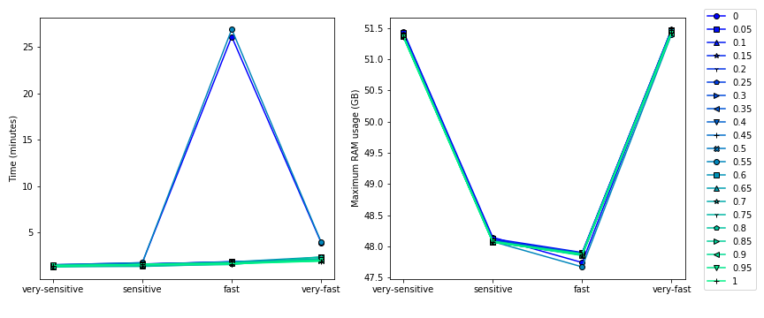

### Methods (RefSeq Complete)

So now I’ll do the same but with the full NCBI RefSeq database:

```r
mkdir kraken2_refseq/kraken2_outraw
mkdir kraken2_refseq/kraken2_kreport
mkdir times

sudo cp -r /home/shared/Kraken2.0.8_Bracken150mer_RefSeqCompleteV93/ /scratch/ramdisk/

parallel -j 1 '(/usr/bin/time -v kraken2 --use-names --threads 12 --db /scratch/ramdisk/Kraken2.0.8_Bracken150mer_RefSeqCompleteV93/ --memory-mapping {1} --output kraken2_refseq/kraken2_outraw/{1/.}.{2}.kraken.txt --report kraken2_refseq/kraken2_kreport/{1/.}.{2}.kreport --confidence {2}) 2> kraken2_refseq/times/time_{1/.}_{2}_.txt' ::: cat_lanes/*.fastq ::: 0 0.05 0.1 0.15 0.2 0.25 0.3 0.35 0.4 0.45 0.5

parallel -j 1 'bracken -d /scratch/ramdisk/Kraken2.0.8_Bracken150mer_RefSeqCompleteV93/ -i {} -l S -o {.}.bracken -r 150' ::: kraken2_refseq/kraken2_kreport/*.kreport
```

Redo with other confidence parameters:

```r
sudo cp -r /home/shared/Kraken2.0.8_Bracken150mer_RefSeqCompleteV93/ /scratch/ramdisk/

parallel -j 1 '(/usr/bin/time -v kraken2 --use-names --threads 12 --db /scratch/ramdisk/Kraken2.0.8_Bracken150mer_RefSeqCompleteV93/ --memory-mapping {1} --output kraken2_refseq/kraken2_outraw/{1/.}.{2}.kraken.txt --report kraken2_refseq/kraken2_kreport/{1/.}.{2}.kreport --confidence {2}) 2> kraken2_refseq/times/time_{1/.}_{2}_.txt' ::: cat_lanes/*.fastq ::: 0.55 0.6 0.65 0.7 0.75 0.8 0.85 0.9 0.95 1

parallel -j 1 'bracken -d /scratch/ramdisk/Kraken2.0.8_Bracken150mer_RefSeqCompleteV93/ -i {} -l S -o {.}.bracken -r 150' ::: kraken2_refseq/kraken2_kreport/*.kreport
```

#### Time to run

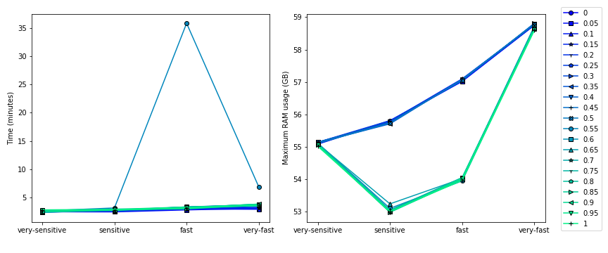

### Results (GTDB + human)

All of the results shown here are based on the number of reads estimated to belong to each taxon by Bracken.

Import data (including on the higher taxonomy levels for each species):

#### Domain-level classifications

Sorted by bowtie2 option:

Sorted by kraken confidence parameter:

All together:

#### Number of bacterial reads

#### Bacterial diversity

Get dataframe of number of bacterial reads (total 5270 species), convert to relative abundance and remove species with below a maximum of 0.1% relative abundance (73 species remaining):

```python
for a in range(len(all_output)):
  for b in range(len(all_output[a])):
    sample_name = bowtie_options[a]+'_'+str(kraken_options[b])
    sample_table = all_output[a][b]
    sample_table['species'] = sample_table.index.values
    sample_table = sample_table.rename(index=sp_dom_dict)
    sample_table = pd.DataFrame(sample_table.loc['d__Bacteria', :])
    sample_table = pd.DataFrame(sample_table.set_index('species').loc[:, 'new_est_reads'])
    if a == 0 and b == 0:
      all_bacteria_reads = pd.DataFrame(sample_table.rename(columns={'new_est_reads':sample_name}))
    else:
      all_bacteria_reads = pd.concat([all_bacteria_reads, sample_table.rename(columns={'new_est_reads':sample_name})]).fillna(value=0)
all_bacteria_reads = all_bacteria_reads.groupby(by=all_bacteria_reads.index, axis=0).sum()
all_bacteria_percent = all_bacteria_reads.divide(all_bacteria_reads.sum(axis=0), axis=1).multiply(100)
all_bacteria_percent_rem = all_bacteria_percent[all_bacteria_percent.max(axis=1) >= 0.1]
```

##### Richness

All species:

Only species above 0.1% abundance:

##### Shannon

Diversity function:

All species:

Only species above 0.1% abundance:

##### Simpsons

All species:

Only species above 0.1% abundance:

#### Beta diversity

Based on Bray-Curtis diversity calculated with either all bacterial species or only those that are present at above 0.1% relative abundance.

#### Dendrogram with abundance

Here I am using all species for Bray-Curtis distance (with Ward linkage) calculation, but only plotting those that are above 0.1% abundance. Species are normalised within each row.

#### Bacterial genus stacked bars (relative abundance)

Plots showing stacked bars of bacterial genera. Just grouping by genus reduces us from 5270 (species) to 2703. If we then remove genera with < 0.1% relative abundance, we have 73 genera (so probably this is the same as the species level, but we could be accounting for slightly more relative abundance). I’ve removed those below 0.5%, to give only 29 genera.

#### Bacterial genus stacked bars (abundance)

Plots showing stacked bars of bacterial genera. Just grouping by genus reduces us from 5270 (species) to 2703. Here I’ve just kept the top 30 bacterial genera (by mean read number).

### Results (RefSeq Complete)

All of the results shown here are based on the number of reads estimated to belong to each taxon by Bracken.

Import data (including on the higher taxonomy levels for each species):

#### Domain-level classifications

Sorted by bowtie2 option:

Sorted by kraken confidence parameter:

All together:

#### Number of bacterial reads

#### Bacterial diversity

Get dataframe of number of bacterial reads (total 793 species), convert to relative abundance and remove species with below a maximum of 0.1% relative abundance (67 species remaining):

```python
for a in range(len(all_output)):
  for b in range(len(all_output[a])):
    sample_name = bowtie_options[a]+'_'+str(kraken_options[b])
    sample_table = all_output[a][b]
    sample_table['species'] = sample_table.index.values
    sample_table = sample_table.rename(index=sp_dom_dict)
    sample_table = pd.DataFrame(sample_table.loc['d__Bacteria', :])
    sample_table = pd.DataFrame(sample_table.set_index('species').loc[:, 'new_est_reads'])
    if a == 0 and b == 0:
      all_bacteria_reads = pd.DataFrame(sample_table.rename(columns={'new_est_reads':sample_name}))
    else:
      all_bacteria_reads = pd.concat([all_bacteria_reads, sample_table.rename(columns={'new_est_reads':sample_name})]).fillna(value=0)

all_bacteria_reads = all_bacteria_reads.groupby(by=all_bacteria_reads.index, axis=0).sum()
all_bacteria_percent = all_bacteria_reads.divide(all_bacteria_reads.sum(axis=0), axis=1).multiply(100)
all_bacteria_percent_rem = all_bacteria_percent[all_bacteria_percent.max(axis=1) >= 0.1]
```

##### Richness

All species:

Only species above 0.1% abundance:

##### Shannon

All species:

Only species above 0.1% abundance:

##### Simpsons

All species:

Only species above 0.1% abundance:

#### Beta diversity

Based on Bray-Curtis diversity calculated with either all bacterial species or only those that are present at above 0.1% relative abundance.

#### Dendrogram with abundance

Here I am using all species for Bray-Curtis distance (with Ward linkage) calculation, but only plotting those that are above 0.1% abundance. Species are normalised within each row.

#### Bacterial genus stacked bars (relative abundance)

Plots showing stacked bars of bacterial genera. Just grouping by genus reduces us from 793 (species) to 340. If we then remove genera with < 0.1% relative abundance, we have 46 genera. I’ve removed those below 0.5%, to give only 28 genera.

#### Bacterial genus stacked bars (abundance)

Plots showing stacked bars of bacterial genera. Here I’ve just kept the top 30 bacterial genera (by mean read number).

## Test human genome

### Chop up the genome

Initial explore the genome

```r
from Bio import SeqIO
from Bio.SeqRecord import SeqRecord
f = 'GCF_000001405.39_GRCh38.p13_genomic.fna'
records = SeqIO.parse(f, "fasta")
count = 0
for record in records:
  count += len(record.seq)

print(count)
```

This gives: 3,272,089,205 bases

Now get the average length of reads in our human genome:

```r
from Bio import SeqIO
from Bio.SeqRecord import SeqRecord
import numpy as np
import os

fol = 'cat_lanes/'
files = os.listdir(fol)
for f in files:
  seq_len = []
  records = SeqIO.parse(fol+f, "fastq")
  for record in records:
    seq_len.append(len(record.seq))
  print(f, 'mean = ', str(np.mean(seq_len)), 'median = ', str(np.median(seq_len)), 'minimum=', str(np.min(seq_len)), 'maximum=', str(np.max(seq_len)), 'standard deviation=', str(np.std(seq_len)))
```

This gives: `PGPC1_very-fast.fastq mean = 126.0189794539796 median = 139.0 minimum= 50 maximum= 151 standard deviation= 29.32198162013586`  
`PGPC1_fast.fastq mean = 127.54254356766751 median = 142.0 minimum= 50 maximum= 151 standard deviation= 28.74779915431567`  
`PGPC1_very-sensitive.fastq mean = 129.20685581054298 median = 145.0 minimum= 50 maximum= 151 standard deviation= 28.163537142041392`  
`PGPC1_sensitive.fastq mean = 128.37165658098488 median = 143.0 minimum= 50 maximum= 151 standard deviation= 28.415484446848374`

Count number of sequences in fasta files:

```r
from Bio import SeqIO
import os

fol = 'cat_lanes/'
files = os.listdir(fol)
for f in files:
  records = SeqIO.parse(fol+f, "fastq")
  count = 0
  for record in records:
    count += 1
  print(f, count)
```

This gives: `PGPC1_very-fast.fastq 6874908`  
`PGPC1_fast.fastq 5642028`  
`PGPC1_sensitive.fastq 4836890`  
`PGPC1_very-sensitive.fastq 4325878`

These files are:  
`2.0G PGPC1_very-fast.fastq` -> 0.290913 b/seq `1.7G PGPC1_fast.fastq` -> 0.3013101 b/seq `1.4G PGPC1_sensitive.fastq` -> 0.2894422 b/seq `1.3G PGPC1_very-sensitive.fastq` -> 0.300517 b/seq

```r
from Bio import SeqIO
from Bio.SeqRecord import SeqRecord
import random

f = 'GCF_000001405.39_GRCh38.p13_genomic.fna'
records = SeqIO.parse(f, "fasta")
one_sequence = ''
for record in records:
  one_sequence += str(record.seq)

max_length, avg, stdev = 3272089205, 127.785, 28.6622
#nseqs = 600000000
nseqs = 100

this_fasta = []
for a in range(0, nseqs):
  rn = int(random.normalvariate(avg, stdev))
  start = random.randint(0, max_length-1-rn)
  this_fasta.append(SeqRecord(Seq(one_sequence[start:start+rn].capitalize()), id='Sequence'+str(a+1), description='Chunk '+str(start)+':'+str(start+rn)))

SeqIO.write(this_fasta, "human_genome_chunks.fasta", "fasta")
```

### Classify with GTDB

```r
sudo cp -r /home/shared/Kraken2_GTDB_human_Dec2020/ /scratch/ramdisk/

mkdir kraken2_gtdb_human
mkdir kraken2_gtdb_human/times
mkdir kraken2_gtdb_human/kraken2_outraw
mkdir kraken2_gtdb_human/kraken2_kreport

parallel -j 1 '(/usr/bin/time -v kraken2 --use-names --threads 12 --db /scratch/ramdisk/Kraken2_GTDB_human_Dec2020/ --memory-mapping {1} --output kraken2_gtdb_human/kraken2_outraw/{1/.}.{2}.kraken.txt --report kraken2_gtdb_human/kraken2_kreport/{1/.}.{2}.kreport --confidence {2}) 2> kraken2_gtdb_human/times/time_{1/.}_{2}_.txt' ::: human_genome_chunks.fasta ::: 0 0.2 0.4 0.6 0.8 1

parallel -j 1 'bracken -d /scratch/ramdisk/Kraken2_GTDB_human_Dec2020/ -i {} -l S -o {.}.bracken -r 150' ::: kraken2_gtdb_human/kraken2_kreport/*.kreport
```

#### Time to run

#### Import data

#### Domain-level classifications

#### Bacterial reads

#### Bacteria stacked bar

Get bacteria:

```python
for b in range(len(all_output)):
    sample_name = str(kraken_options[b])
    sample_table = all_output[b]
    sample_table['species'] = sample_table.index.values
    sample_table = sample_table.rename(index=sp_dom_dict)
    sample_table = pd.DataFrame(sample_table.loc['d__Bacteria', :])
    sample_table = pd.DataFrame(sample_table.set_index('species').loc[:, 'new_est_reads'])
    if b == 0:
      all_bacteria_reads = pd.DataFrame(sample_table.rename(columns={'new_est_reads':sample_name}))
    else:
      all_bacteria_reads = pd.concat([all_bacteria_reads, sample_table.rename(columns={'new_est_reads':sample_name})]).fillna(value=0)
all_bacteria_reads = all_bacteria_reads.groupby(by=all_bacteria_reads.index, axis=0).sum()
all_bacteria_percent = all_bacteria_reads.divide(all_bacteria_reads.sum(axis=0), axis=1).multiply(100)

genus = {}
species = list(all_bacteria_percent.index.values)
for sp in species:
  genus[sp] = sp.split(' ')[0].split('__')[1]

all_bacteria_genus = all_bacteria_percent.rename(index=genus)
all_bacteria_genus = all_bacteria_genus.groupby(by=all_bacteria_genus.index).sum()
all_bacteria_genus_rem = all_bacteria_genus[all_bacteria_genus.max(axis=1) >= 0.1]

all_bacteria_genus_reads = all_bacteria_reads.rename(index=genus)
all_bacteria_genus_reads = all_bacteria_genus_reads.groupby(by=all_bacteria_genus_reads.index).sum()
```

If we keep all bacteria, we have 23,541 species. If we only keep those that are above 0.1% relative abundance then we have 250 species, above 0.5% 77 species and above 1% 64 species. If we group to genus and remove those that are above 0.1% we have 307 genera, 0.5% we have 78 genera, 1% we have 63 genera and 2% we have 12 species. This is all genera above 0.1% abundance:

If we now show just those above 2% abundance:

### Classify with RefSeq Complete

I started running this like this and it’s using a lot of memory, so splitting into 10 files

```r
sudo cp -r /home/shared/Kraken2.0.8_Bracken150mer_RefSeqCompleteV93/ /scratch/ramdisk/

mkdir kraken2_refseq
mkdir kraken2_refseq/times
mkdir kraken2_refseq/kraken2_outraw
mkdir kraken2_refseq/kraken2_kreport

parallel -j 1 '(/usr/bin/time -v kraken2 --use-names --threads 12 --db /scratch/ramdisk/Kraken2.0.8_Bracken150mer_RefSeqCompleteV93/ --memory-mapping {1} --output kraken2_refseq/kraken2_outraw/{1/.}.{2}.kraken.txt --report kraken2_refseq/kraken2_kreport/{1/.}.{2}.kreport --confidence {2}) 2> kraken2_refseq/times/time_{1/.}_{2}_.txt' ::: human_genome_chunks.fasta ::: 0 0.2 0.4 0.6 0.8 1
```

Split:

```r
#split -n 10 --numeric-suffixes human_genome_chunks.fasta human_genome_chunks_part #-> this led to the file formats not being right because some of the headers were taken without the sequences
split -l 250000000 --numeric-suffixes human_genome_chunks.fasta human_genome_chunks_part
for i in human_genome_chunks_part* ; do mv $i $i.fasta ; done
```

Just splitting to 10 files gave some of the split files starting with the sequence rather than the ID. If we split based on the number of lines that each file should have then still some files started with the sequence. So will need to script this:

```r
import os
from Bio import SeqIO
from Bio.SeqRecord import SeqRecord
import subprocess

def split_file(file, parts):
  records = SeqIO.parse(file, "fasta")
  count, part, new_file = 0, 1, []
  fn = file.replace('.fasta', '')
  for record in records:
    new_file.append(record)
    count += 1
    if count == 60000000:
      SeqIO.write(new_file, fn+'_'+str(part)+'.fasta', "fasta")
      count, new_file = 0, []
      part += 1
  return

file = 'human_genome_chunks.fasta'
split_file(file, 10)
```

So this gives 10 files with the file name: human_genome_chunks_*.fasta

Now run:

```r
parallel -j 1 '(/usr/bin/time -v kraken2 --use-names --threads 24 --db /scratch/ramdisk/Kraken2.0.8_Bracken150mer_RefSeqCompleteV93/ --memory-mapping {1} --output kraken2_refseq/kraken2_outraw/{1/.}.{2}.kraken.txt --report kraken2_refseq/kraken2_kreport/{1/.}.{2}.kreport --confidence {2}) 2> kraken2_refseq/times/time_{1/.}_{2}_.txt' ::: human_genome_chunks_*.fasta ::: 0 0.2 0.4 0.6 0.8 1

parallel -j 1 'bracken -d /scratch/ramdisk/Kraken2.0.8_Bracken150mer_RefSeqCompleteV93/ -i {} -l S -o {.}.bracken -r 150' ::: kraken2_refseq/kraken2_kreport/*.kreport
```

#### Time to run

#### Import data

#### Domain-level classifications

#### Bacterial reads

At a confidence parameter of 0.6 we have 19 reads.

#### Bacteria stacked bar

Get bacteria:

```python
for b in range(len(all_output)):
    sample_name = str(kraken_options[b])
    sample_table = all_output[b]
    sample_table['species'] = sample_table.index.values
    sample_table = sample_table.rename(index=sp_dom_dict)
    try:
      sample_table = pd.DataFrame(sample_table.loc['d__Bacteria', :])
      sample_table = pd.DataFrame(sample_table.set_index('species').loc[:, 'new_est_reads'])
      if b == 0:
        all_bacteria_reads = pd.DataFrame(sample_table.rename(columns={'new_est_reads':sample_name}))
      else:
        all_bacteria_reads = pd.concat([all_bacteria_reads, sample_table.rename(columns={'new_est_reads':sample_name})]).fillna(value=0)
    except:
      no_bacteria = True

all_bacteria_reads = all_bacteria_reads.groupby(by=all_bacteria_reads.index, axis=0).sum()
all_bacteria_percent = all_bacteria_reads.divide(all_bacteria_reads.sum(axis=0), axis=1).multiply(100)

genus = {}
species = list(all_bacteria_percent.index.values)
for sp in species:
  genus[sp] = sp.split(' ')[0]

all_bacteria_genus = all_bacteria_percent.rename(index=genus)
all_bacteria_genus = all_bacteria_genus.groupby(by=all_bacteria_genus.index).sum()

all_bacteria_genus_reads = all_bacteria_reads.rename(index=genus)
all_bacteria_genus_reads = all_bacteria_genus_reads.groupby(by=all_bacteria_genus_reads.index).sum()
```

If we keep all bacteria, we have 11 species and 9 genera, so I’m plotting all of them.

### Kneaddata/Bowtie2

Look at removing low complexity sequences using dustmasker

### Kneaddata + classify with GTDB

### Kneaddata + classify with RefSeq Complete

# Run everything through kneaddata

## Get participant download links

Run this script on vulcan, it will save a pickle dictionary containing links for all files related to each participant:

```r
import os
import subprocess
import pickle

participants = {}
participant_numbers = [1, 2, 3, 4, 5, 6, 7, 8, 9, 10, 11, 12, 13, 14, 15, 16, 17, 18, 19, 20, 21, 22, 23, 24, 25, 26, 27, 28, 29, 30, 31, 32, 33, 34, 35, 36, 37, 38, 39, 40, 41, 42, 43, 44, 45, 46, 47, 48, 49, 50, 51, 52, 53, 54, 55, 56, 57, 59, 61, 62, 67, 69, 70, 71, 72, 73, 74, 76, 77, 78, 82, 87]
for num in participant_numbers:
  participants['PGPC_'+str(num).zfill(4)] = []

for a in range(0, 3000):
  try:
      link = "https://personalgenomes.ca/v1/public/files/"+str(a)+"/download"
      output = subprocess.check_output("wget --spider --server-response "+link+" 2>&1 | grep -i content-disposition", shell=True)
      output = str(output)
      fn = output.split('"')[1]
      if 'md5sum' not in output and 'fastq.gz' in output:
        for participant in participants:
          if participant in fn:
            participants[participant] = participants[participant]+[link]
    except:
        do_nothing = True

with open('participant_links.dict', 'wb') as f:
    pickle.dump(participants, f)
```

This didn’t get all of them because where most are e.g. 0001, some of them are e.g. 54 or 51, so checking the file names didn’t work for all. Modifying the script to get the rest:

```r
import os
import subprocess
import pickle

with open('participant_links.dict', 'rb') as f:
    participants = pickle.load(f)

already_saved = []
for participant in participants:
  if participants[participant] != []:
    already_saved = already_saved+participants[participant]
all_links = {}

for a in range(0, 3000):
  try:
      link = "https://personalgenomes.ca/v1/public/files/"+str(a)+"/download"
      if link in already_saved: continue
      output = subprocess.check_output("wget --spider --server-response "+link+" 2>&1 | grep -i content-disposition", shell=True)
      output = str(output)
      fn = output.split('"')[1]
      if 'md5sum' not in output and 'fastq.gz' in output:
        for participant in participants:
          if participant in fn:
            participants[participant] = participants[participant]+[link]
          elif participant.replace('0', '') in fn:
            participants[participant] = participants[participant]+[link]
      all_links[link] = fn
  except:
        do_nothing = True

with open('participant_links_2.dict', 'wb') as f:
    pickle.dump(participants, f)

with open('all_links.dict', 'wb') as f:
    pickle.dump(all_links, f)
```

This time I ended up adding to too many because I removed too many zeroes when checking which participant to add the link to, so I fixed it like this:

```r
import os
import subprocess
import pickle

with open('/Users/robynwright/Documents/OneDrive/Langille_Lab_postdoc/Human_blood_metagenome/run_on_server/sort_links/participant_links_2.dict', 'rb') as f:
    participants = pickle.load(f)

with open('/Users/robynwright/Documents/OneDrive/Langille_Lab_postdoc/Human_blood_metagenome/run_on_server/sort_links/all_links.dict', 'rb') as f:
    all_links = pickle.load(f)

new_participants = {}
for participant in participants:
    new_links = []
    for link in participants[participant]:
        if link in all_links:
            file = all_links[link]
            if '.md5' not in file and participant in file:
                print(participant, file)
            elif '.md5' not in file and 'PGPC_'+participant[7:] in file:
                new_links.append(link)
        else:
            new_links.append(link)
    new_participants[participant] = new_links

with open('/Users/robynwright/Documents/OneDrive/Langille_Lab_postdoc/Human_blood_metagenome/run_on_server/sort_links/participant_links_3.dict', 'wb') as f:
    pickle.dump(new_participants, f)
```

I checked several at random to see that the number of files was correct and it all looks good.

## Run through all participants

```r
import os
import subprocess
import pickle
import numpy as np
from Bio import SeqIO

threads = '40'

with open('participant_links_3.dict', 'rb') as f:
    participants = pickle.load(f)

def print_and_log(message, log):
  log.append(message)
  print(message)
  return log

def split_file(file, num_records, total):
  records = SeqIO.parse(file, "fasta")
  count, count_file, part, new_file = 0, 1, 1, []
  fn = file.replace('.fasta', '')
  files = []
  for record in records:
    new_file.append(record)
    count += 1
    count_file += 1
    if count == num_records or count_file == total:
      SeqIO.write(new_file, fn+'_'+str(part)+'.fasta', "fasta")
      files.append(fn+'_'+str(part)+'.fasta')
      count, new_file = 0, []
      part += 1
  return files

def download_files(directory, links, log):
  log = print_and_log('Downloading links to directory '+directory, log)
  files = []
  for link in links:
    log = print_and_log('Getting '+link, log)
    #if we already have this file, continue to the next link
    output = subprocess.check_output("wget --spider --server-response "+link+" 2>&1 | grep -i content-disposition", shell=True)
    output = str(output)
    fn = output.split('"')[1]
    fn = fn.replace('_001.', '.')
    log = print_and_log('Checking for file '+fn, log)
    if os.path.exists(directory+'/'+fn):
        files.append(fn)
        log = print_and_log('Already have '+fn, log)
        continue
    log = print_and_log("Didn't have it, so downloading "+fn+" from "+link, log)
    command = 'wget '+link+' -O '+directory+'/'+fn
    os.system(command)
    if not os.path.exists(directory+'/'+fn): log = print_and_log("Didn't get "+fn+" from link "+link, log)
    else:
        files.append(fn)
        log = print_and_log("Got "+fn+" from link "+link, log)

  #Sort the files into pairs of R1 and R2
  files = sorted(list(set(files)))
  sorted_files, already_added = [], []
  for file in files:
    if file in already_added: continue
    if file.replace('R1', 'R2') in files:
      sorted_files.append(sorted([file, file.replace('R1', 'R2')]))
      already_added = already_added+[file, file.replace('R1', 'R2')]
      log = print_and_log('New pair: '+file+', '+file.replace('R1', 'R2'), log)
    elif file.replace('R2', 'R1') in files:
      sorted_files.append(sorted([file, file.replace('R2', 'R1')]))
      already_added = already_added+[file, file.replace('R2', 'R1')]
      log = print_and_log('New pair: '+file+', '+file.replace('R2', 'R1'), log)
  return log, sorted_files

def check_and_split_file(directory, files, log):
  #for each file set - R1 and R2 pair - check if the size is larger than 10 GB. If it is, add it to the list of files that need splitting
  log = print_and_log('Checking for files that need splitting for '+directory, log)
  need_splitting = []
  for file_set in files:
    size1, size2 = os.stat(directory+'/'+file_set[0]).st_size, os.stat(directory+'/'+file_set[1]).st_size
    if size1/1000000000 > 10 or size2/1000000000 > 10:
      need_splitting.append(file_set+[size1/1000000000])
  new_files = []

  if need_splitting == []:#if it's not, just return the log file and the file list
    log = print_and_log("Didn't need to split any files for "+directory, log)
    return log, files
  else:
    for file_set in files:
      if file_set not in need_splitting:
        new_files.append(file_set)
    for file_set in need_splitting:
      #unzip both files
      os.system('gunzip '+directory+'/'+file_set[0])
      os.system('gunzip '+directory+'/'+file_set[1])
      f1, f2 = directory+'/'+file_set[0].replace('.gz', ''), directory+'/'+file_set[1].replace('.gz', '')
      #check if number of records is the same in each
      count1, count2 = 0, 0
      for rec in SeqIO.parse(f1, "fastq"):
             count1 += 1
      for rec in SeqIO.parse(f2, "fastq"):
             count2 += 1
      if count1 != count2:
        log = print_and_log("Couldn't split files "+file_set[0]+" and "+file_set[1]+" because they didn't have the same number of lines. "+file_set[0]+" has "+str(count1)+" lines while "+file_set[1]+" has "+str(count2)+" lines", log)
        os.system('gzip '+f1)
        os.system('gzip '+f2)
        continue
      else:
        num_files = np.ceil(file_set[2]/10)
        records_per_file = np.ceil(count1/num_files)
        first = split_file(f1, records_per_file, count1)
        log = print_and_log('Split the files '+f1+' into '+str(num_files)+' files', log)
        second = split_file(f2, records_per_file, count1)
        log = print_and_log('Split the files '+f2+' into '+str(num_files)+' files', log)
        these_files = []
        for f in first:
          if f.replace('R1', 'R2') in second:
            log = print_and_log('gzipping '+f, log)
            os.system('gzip '+f)
            log = print_and_log('gzipping '+f.replace('R1', 'R2'), log)
            os.system('gzip '+f.replace('R1', 'R2'))
            these_files.append(sorted([f+'.gz', f.replace('R1', 'R2')+'.gz']))
          elif f.replace('R2', 'R1') in second:
            log = print_and_log('gzipping '+f, log)
            os.system('gzip '+f)
            log = print_and_log('gzipping '+f.replace('R2', 'R1'), log)
            os.system('gzip '+f.replace('R2', 'R1'))
            these_files.append(sorted([f+'.gz', f.replace('R2', 'R1')+'.gz']))
        log = print_and_log("Successfully split all parts of "+file_set[:2], log)

        new_files = new_files+these_files
  for f in range(len(new_files)):
    if '/' in new_files[f]:
      new_files[f] = new_files[f].split('/')[1]
  return log, new_files

def run_kneaddata(directory, files, log):
  for file_set in files:
    f1, f2 = directory+'/'+file_set[0], directory+'/'+file_set[1]
    log = print_and_log('Checking for previous kneaddata file', log)
    if not os.path.exists(directory+'/'+'kneaddata_out/'+file_set[0].replace('.fastq.qz', '')+'_kneaddata_paired.fastq.gz'):
        log = print_and_log("Didn't have "+directory+'/'+'kneaddata_out/'+file_set[0].replace('.fastq.qz', '')+'_kneaddata_paired.fastq.gz', log)
        log = print_and_log('Unzipping '+f1+' and '+f2, log)
        os.system('gunzip '+f1)
        os.system('gunzip '+f2)
        f1, f2 = f1.replace('.gz', ''), f2.replace('.gz', '')
        log = print_and_log('Running kneaddata with '+f1+' and '+f2, log)
        command = 'kneaddata -i '+f1+' -i '+f2+' -o '+directory+'/kneaddata_out/ -db /home/shared/bowtiedb/GRCh38_PhiX --trimmomatic /home/robyn/tools/Trimmomatic-0.39/ -t '+threads+' --trimmomatic-options "SLIDINGWINDOW:4:20 MINLEN:50" --bowtie2-options "--very-sensitive --dovetail" --remove-intermediate-output'
        os.system(command)
        log = print_and_log('Zipping '+f1+' and '+f2, log)
        os.system('gzip '+f1)
        os.system('gzip '+f2)
    output_list = os.listdir(directory+'/kneaddata_out/')
    if output_list == 1: log = print_and_log("Something happened and kneaddata didnt run properly with "+f1+' and '+f2, log)
    else: log = print_and_log('Looks like kneaddata at least created some files', log)
    for out in output_list:
      if '.log' not in out and 'kneaddata_paired' not in out:
        os.system('rm '+directory+'/'+out)
        log = print_and_log('Removed '+directory+'/'+out, log)
      elif '.log' in out:
        log = print_and_log('Got a kneaddata log file ', log)
      elif 'kneaddata_paired' in out:
        if '.gz' not in out:
            os.system('gzip '+directory+'/kneaddata_out/'+out)
        log = print_and_log('Got and zipped '+out, log)
  return log

def remove_fasta(directory, files, log):
  log = print_and_log('Beginning to remove fasta files from '+directory, log)
  for file in files:
    try:
      os.system('rm '+directory+'/'+file)
      log = print_and_log('Removed '+directory+'/'+file, log)
    except:
      log = print_and_log("Didn't manage to remove "+directory+'/'+file, log)
  log = print_and_log('Removed all the files we could from '+directory, log)
  return log

def write_logfile(directory, log):
  with open(directory+'/log.txt', 'w') as f:
    for row in log:
      f.write(row+'\n')
  return

for participant in participants:
  log = []
  if participant != 'PGPC_0002': continue
  if os.path.exists(participant):
      have_knead = False
      if os.path.exists(participant+'/kneaddata_out/'):
          for file in os.listdir(participant+'/kneaddata_out/'):
              if 'kneaddata_paired' in file:
                  have_knead = True
                  break
      if not have_knead:
          log = print_and_log('Already had the directory for '+participant+', but no kneaddata_paired file so continuing', log)
      else:
          log = print_and_log('Already have at least one kneaddata_paired file for '+participant+', so moving onto the next participant', log)
          write_logfile(participant, log)
          break
  else:
      os.system('mkdir '+participant)
      log = print_and_log('Made the directory for '+participant, log)
  links = list(set(participants[participant]))

  try:
    #Download all files to the new directory, returning the log file and a list of the files sorted into R1 and R2 pairs
    log = print_and_log('Starting the download function for '+participant, log)
    log, sorted_files = download_files(participant, links, log)
    log = print_and_log('Finished the download function for '+participant, log)
  except:
    log = print_and_log('Something happened with the download function for '+participant, log)
    write_logfile(participant, log)
    continue

  try:
    #Split the files to smaller files if needed
    log, sorted_files = check_and_split_file(participant, sorted_files, log)
    log = print_and_log('Finished the split function for '+participant, log)
  except:
    log = print_and_log('Something happened with the split function for '+participant, log)
    write_logfile(participant, log)
    continue

  try:
    #Run kneaddata on each file set
    log = run_kneaddata(participant, sorted_files, log)
    log = print_and_log('Finished the kneaddata function for '+participant, log)
  except:
    log = print_and_log('Something happened with the kneaddata function for '+participant, log)
    write_logfile(participant, log)
    continue

  try:
    #Remove the fasta files
    remove_fasta(participant, sorted_files, log)
  except:
    log = print_and_log('Something happened with the remove fasta function for '+participant, log)
    write_logfile(participant, log)
    continue

  #Write log file
  write_logfile(participant, log)
```

Keep getting kneaddata/trimmomatic/java errors. Tried running kneaddata directly and still get an error:

```r
kneaddata -i PGPC_0002_S1_L001_R1.fastq -i PGPC_0002_S1_L001_R2.fastq -o kneaddata_out/ -db /home/shared/bowtiedb/GRCh38_PhiX --trimmomatic /home/robyn/tools/Trimmomatic-0.39/ -t 20 --trimmomatic-options "SLIDINGWINDOW:4:20 MINLEN:50" --bowtie2-options "--very-sensitive --dovetail" --remove-intermediate-output
Reformatting file sequence identifiers ...

Reformatting file sequence identifiers ...

Initial number of reads ( /home/robyn/human_blood/kneaddata_all_participants/PGPC_0002/kneaddata_out/reformatted_identifiersr9ltMI_PGPC_0002_S1_L001_R1 ): 71760200
Initial number of reads ( /home/robyn/human_blood/kneaddata_all_participants/PGPC_0002/kneaddata_out/reformatted_identifiersrAyq4P_PGPC_0002_S1_L001_R2 ): 71760200
Running Trimmomatic ...
CRITICAL ERROR: Error executing: java -Xmx500m -jar /home/robyn/tools/Trimmomatic-0.39/trimmomatic-0.39.jar PE -threads 20 -phred33 /home/robyn/human_blood/kneaddata_all_participants/PGPC_0002/kneaddata_out/reformatted_identifiersr9ltMI_PGPC_0002_S1_L001_R1 /home/robyn/human_blood/kneaddata_all_participants/PGPC_0002/kneaddata_out/reformatted_identifiersrAyq4P_PGPC_0002_S1_L001_R2 /home/robyn/human_blood/kneaddata_all_participants/PGPC_0002/kneaddata_out/PGPC_0002_S1_L001_R1_kneaddata.trimmed.1.fastq /home/robyn/human_blood/kneaddata_all_participants/PGPC_0002/kneaddata_out/PGPC_0002_S1_L001_R1_kneaddata.trimmed.single.1.fastq /home/robyn/human_blood/kneaddata_all_participants/PGPC_0002/kneaddata_out/PGPC_0002_S1_L001_R1_kneaddata.trimmed.2.fastq /home/robyn/human_blood/kneaddata_all_participants/PGPC_0002/kneaddata_out/PGPC_0002_S1_L001_R1_kneaddata.trimmed.single.2.fastq SLIDINGWINDOW:4:20 MINLEN:50

Error message returned from Trimmomatic :
java: error while loading shared libraries: libjli.so: cannot open shared object file: No such file or directory
```

Trying with parallel like usual:

```r
parallel -j 1 --link --progress 'kneaddata -i {1} -i {2} -o kneaddata_out/ \
-db /home/shared/bowtiedb/GRCh38_PhiX --trimmomatic /home/robyn/tools/Trimmomatic-0.39/ \
-t 20 --trimmomatic-options "SLIDINGWINDOW:4:20 MINLEN:50" \
--bowtie2-options "--very-sensitive --dovetail" --remove-intermediate-output' \
 ::: PGPC_0002_S1_L001_R1.fastq ::: PGPC_0002_S1_L001_R2.fastq
```

Also now not working? Trying on a file I know works:

```r
parallel -j 1 --link --progress 'kneaddata -i {1} -i {2} -o kneaddata_out/ \
-db /home/shared/bowtiedb/GRCh38_PhiX --trimmomatic /home/robyn/tools/Trimmomatic-0.39/ \
-t 20 --trimmomatic-options "SLIDINGWINDOW:4:20 MINLEN:50" \
--bowtie2-options "--very-sensitive --dovetail" --remove-intermediate-output' \
 ::: PGPC_0001_S2_L001_R1_001.fastq.gz ::: PGPC_0001_S2_L001_R2_001.fastq.gz

Decompressing gzipped file ...

Reformatting file sequence identifiers ...

Reformatting file sequence identifiers ...

Initial number of reads ( /home/robyn/human_blood/kneaddata_all_participants/PGPC_0001/kneaddata_out/reformatted_identifiersKJxCEj_decompressed_u3uQqc_PGPC_0001_S2_L001_R2_001 ): 58716973
Initial number of reads ( /home/robyn/human_blood/kneaddata_all_participants/PGPC_0001/kneaddata_out/reformatted_identifierskJy0nE_decompressed_JCmV4s_PGPC_0001_S2_L001_R1_001 ): 58716973
Running Trimmomatic ...
CRITICAL ERROR: Error executing: java -Xmx500m -jar /home/robyn/tools/Trimmomatic-0.39/trimmomatic-0.39.jar PE -threads 20 -phred33 /home/robyn/human_blood/kneaddata_all_participants/PGPC_0001/kneaddata_out/reformatted_identifierskJy0nE_decompressed_JCmV4s_PGPC_0001_S2_L001_R1_001 /home/robyn/human_blood/kneaddata_all_participants/PGPC_0001/kneaddata_out/reformatted_identifiersKJxCEj_decompressed_u3uQqc_PGPC_0001_S2_L001_R2_001 /home/robyn/human_blood/kneaddata_all_participants/PGPC_0001/kneaddata_out/PGPC_0001_S2_L001_R1_001_kneaddata.trimmed.1.fastq /home/robyn/human_blood/kneaddata_all_participants/PGPC_0001/kneaddata_out/PGPC_0001_S2_L001_R1_001_kneaddata.trimmed.single.1.fastq /home/robyn/human_blood/kneaddata_all_participants/PGPC_0001/kneaddata_out/PGPC_0001_S2_L001_R1_001_kneaddata.trimmed.2.fastq /home/robyn/human_blood/kneaddata_all_participants/PGPC_0001/kneaddata_out/PGPC_0001_S2_L001_R1_001_kneaddata.trimmed.single.2.fastq SLIDINGWINDOW:4:20 MINLEN:50

Error message returned from Trimmomatic :
java: error while loading shared libraries: libjli.so: cannot open shared object file: No such file or directory

local:0/1/100%/763.0s
```

Still having the java issue.

Removed trimmomatic and reinstalled with conda - kneaddata doesn’t find it this way so downloaded from binary on the website again Installed bowtie2 with conda Installed kneaddata with conda

Trying again:

```r
parallel -j 1 --link --progress 'kneaddata -i {1} -i {2} -o kneaddata_out/ \
-db /home/shared/bowtiedb/GRCh38_PhiX --trimmomatic /home/robyn/tools/Trimmomatic-0.39/ \
-t 20 --trimmomatic-options "SLIDINGWINDOW:4:20 MINLEN:50" \
--bowtie2-options "--very-sensitive --dovetail" --remove-intermediate-output' \
 ::: PGPC_0001_S2_L001_R1_001.fastq.gz ::: PGPC_0001_S2_L001_R2_001.fastq.gz
```

Making a new conda environment and seeing if that works:

```r
conda create --name kneaddata
conda activate kneaddata
pip install kneaddata
conda install bowtie2
conda install -c bioconda trf
```